# Homework 2 (HW2)

By the end of this homework we expect you to be able to:

1. Preprocess data and make it amenable to statistical analysis and machine learning models;
2. Train and test out-of-the-box machine learning models in Python;
3. Carry out statistical hypothesis testing;
4. Carry out simple multivariate regression analyses;
5. Use techniques to control for covariates;

## Important Dates

- Homework release: Fri 12 Nov 2021
- **Homework due**: Fri 26 Nov 2021, 23:59
- Grade release: Fri 03 Dec 2021

## Some rules

1. You are allowed to use any built-in Python library that comes with Anaconda. If you want to use an external library, you may do so, but must justify your choice.
2. Make sure you use the `data` folder provided in the repository in read-only mode. (Or alternatively, be sure you don’t change any of the files.)
3. Be sure to provide a textual description of your thought process, the assumptions you made, the solution you implemented, and explanations for your answers. A notebook that only has code cells will not suffice.
4. For questions containing the **/Discuss:/** prefix, answer not with code, but with a textual explanation (**in markdown**).
5. Back up any hypotheses and claims with data, since this is an important aspect of the course.
6. Please write all your comments in English, and use meaningful variable names in your code. Your repo should have a single notebook (plus the required data files) in the *master/main* branch. If there are multiple notebooks present, we will **not grade** anything.
7. We will **not run your notebook for you**! Rather, we will grade it as is, which means that only the results contained in your evaluated code cells will be considered, and we will not see the results in unevaluated code cells. Thus, be sure to hand in a **fully-run and evaluated notebook**. In order to check whether everything looks as intended, you can check the rendered notebook on the GitHub website once you have pushed your solution there.
8. In continuation to the previous point, interactive plots, such as those generated using `plotly`, should be **strictly avoided**!
9. Make sure to print results or dataframes that confirm you have properly addressed the task.

## Context

Congratulations! You have just been hired as a data scientist at *Piccardi Music,* a promising new music label created by a mysterious Italian disc jockey "*Signor Piccardi*". The company hired you to carry out a variety of data-related tasks, which will be explained in further detail below.

## The data

For this homework you will use a dataset of 18,403 music reviews scraped from Pitchfork¹, including relevant metadata such as review author, review date, record release year, review score, and genre, along with the respective album's audio features pulled from Spotify's API. The data consists of the following columns:

| Column | Description |
| --- | --- |
| `artist` | The name of the artist who created the album being reviewed. |
| `album` | The name of the album being reviewed. |
| `recordlabel` | The name of the record label(s) who published the album. |
| `releaseyear` | The year that the album was released. |
| `score` | The score given to the album by the reviewer on a scale of 0.0 to 10.0. |
| `reviewauthor` | The name of the author who reviewed the album. |
| `genre` | The genre assigned to the album by Pitchfork. |
| `reviewdate` | The date that the review was published. |
| `key` | The estimated overall musical key of the track. Integers map to pitches using standard Pitch Class notation (e.g., 0 = C, 2 = D, and so on) |
| `acousticness` | A confidence measure from 0.0 to 1.0 of whether an album is acoustic. 1.0 represents high confidencethat the album is acoustic. |
| `danceability` | How suitable an album is for dancing based on a combination of musical elements including tempo, rhythm stability, beat strength, and overall regularity. A value of 1.0 is most danceable. |
| `energy` | A perceptual measure of intensity and activity, from 0.0 to 1.0, where 1.0 represents high energy. Metal is often high energy. |
| `instrumentalness` | Predicts whether an album contains no vocals, from 0.0 to 1.0. The closer to 1.0, the more likely the album contains no vocals. |
| `liveness` | Detects the presence of an audience, from 0.0 to 1.0. Scores greater than 0.8 indicate a strong likelihood the album is live. |
| `loudness` | The overall loudness of the album in decibels (dB). |
| `speechiness` | Measures the presence of spoken words in an album on a scale from 0.0 to 1.0. Scores higher than 0.66 indicate an album made entirely of spoken words, while scores below 0.33 indicate music and other … |
| `valence` | A measure from 0.0 to 1.0 describing the musical positiveness conveyed by an album, where values closer to 1.0 indicate more positive sounds. |
| `tempo` | The overall estimated tempo of an album in beats per minute (BPM). |

¹Pinter, Anthony T., et al. "P4KxSpotify: A Dataset of Pitchfork Music Reviews and Spotify Musical Features." Proceedings of the International AAAI Conference on Web and Social Media. Vol. 14. 2020.

```python
# CHANGE THIS IF YOU NEED/WANT TOO

# pandas / numpy
import pandas as pd
import numpy as np
rng = np.random.default_rng() # for random number generation

# plotting
import matplotlib.pyplot as plt
import seaborn as sns
from matplotlib import rcParams
from matplotlib.lines import Line2D

# datetime operations
from datetime import datetime

# ttest and euclidean distance
from scipy.stats import ttest_ind
from scipy.spatial.distance import seuclidean

# linear fit using statsmodels
import statsmodels.api as sm
import statsmodels.formula.api as smf

# good ole sklearn
from sklearn.metrics import euclidean_distances, r2_score
from sklearn.linear_model import LinearRegression
from sklearn.ensemble import GradientBoostingRegressor
from sklearn.model_selection import train_test_split

# displaying markdown strings
from IPython.display import display, Markdown, Latex


# settings
rcParams['figure.dpi']= 100
pd.set_option('display.max_rows', 3000)
sns.set(style="whitegrid")


# data folder
#DATA_FOLDER = 'data/'
DATA_FOLDER = r'/Users/geoffraymarie/EPFL/ADA/ADA2021/Homework/02 - Regression Observational Studies Stats and Supervised Learning/data/'
```

## Part 1: Will this album be a hit?

The first project you embark on in your new job is to build a regressor to predict whether an album will be well received or not. According to *Signor Piccardi* (your boss), this algorithm may eventually be helpful in forecasting the success of albums produced by *Piccardi Music*.

**Task 1 (Initial analyses — 10 pts)**

As a good data scientist, the first thing you do is to have a good look at the data that was handed to you.

1. Load the data using `pandas`. Identify and remove duplicate reviews, i.e., two reviews with albums by the same band with the same name (keep the first occurrence). Print the number of rows in your dataframe.

```python
df = pd.read_csv(DATA_FOLDER + 'pitchfork.csv.gz', compression='gzip',
                 parse_dates=['reviewdate'], dtype={'releaseyear': int}
                )
```

```python
shape_before = df.shape[0]
df.drop_duplicates(subset = ['artist','album'], keep = 'first', inplace = True)
print('After removing the duplicate {} reviews, the dataframe has now {} rows.'\
      .format(shape_before - df.shape[0], df.shape[0]))
```

```
After removing the duplicate 47 reviews, the dataframe has now 16738 rows.
```

1. Plot the distribution of album release years and the average score of albums per year.

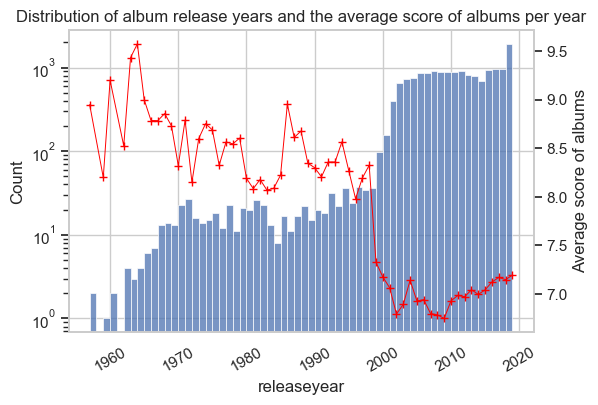

```python
fig, ax1 = plt.subplots()

yearmin, yearmax = df.releaseyear.min(), df.releaseyear.max()

sns.histplot(x = 'releaseyear', stat = 'count', data = df, ax = ax1,
             bins = [k for k in range(yearmin, yearmax + 1)])

ax1.minorticks_on()
ax1.set_yscale('log')
ax1.tick_params(axis='x', labelrotation = 30)

ax2 = ax1.twinx()
ax2.plot(df.groupby('releaseyear').score.agg('mean'), color = 'red', marker = '+', lw = 0.7)
ax2.set_ylabel('Average score of albums');
ax2.grid(None)


plt.title('Distribution of album release years and the average score of albums per year');
```

1. For numerical columns, calculate the mean, median, minimum value and maximum value. Additionally, plot the distribution for all the numerical columns in a single image (possibly with multiple subplots). Your image should be at most 14 inches wide by 14 inches long.

```python
df.describe().loc[['mean', '50%', 'min', 'max']]
```

|  | score | releaseyear | danceability | energy | key | loudness | speechiness | acousticness | instrumentalness | liveness | valence | tempo |
| --- | --- | --- | --- | --- | --- | --- | --- | --- | --- | --- | --- | --- |
| mean | 7.048596 | 2009.346338 | 0.512334 | 0.601276 | 5.216501 | -9.283268 | 0.090742 | 0.301914 | 0.274748 | 0.196402 | 0.405268 | 120.326487 |
| 50% | 7.300000 | 2010.000000 | 0.511348 | 0.624722 | 5.230769 | -8.444263 | 0.056665 | 0.228844 | 0.149363 | 0.174261 | 0.406288 | 120.397346 |
| min | 0.000000 | 1957.000000 | -1.000000 | -1.000000 | -1.000000 | -51.728750 | -1.000000 | -1.000000 | -1.000000 | -1.000000 | -1.000000 | -1.000000 |
| max | 10.000000 | 2019.000000 | 0.974000 | 0.999000 | 11.000000 | 4.078000 | 0.958000 | 0.996000 | 0.982000 | 0.978000 | 0.971000 | 215.972000 |

We observe a problem of range for some categories: - `danceability`, `energy`, `speechiness`, `acousticness`, `instrumentalness`, `liveness`, `valence` should go from **0.0 to 1.0** and some are smaller than 0.0. - `tempo`should be **greater than 0**. We drop the reviews with irregularites and recompute the mean, median, min, max. About the `key`, feature we supposed it was obtained with a programm, explaining why the majority of the data is not integers. We decided to keep it like that.

```python
aberrant_num_columns = ['danceability', 'energy', 'speechiness', 'acousticness', 'instrumentalness',
                        'liveness', 'valence', 'tempo']

to_drop = df[df[aberrant_num_columns].lt(0.0).any(axis = 1)].shape[0]
df = df[~df[aberrant_num_columns].lt(0.0).any(axis = 1)]
print('We removed {} rows with irregular values.'.format(to_drop))
```

[output not shown]

```python
df.describe().loc[['mean', '50%', 'min', 'max']]
```

|  | score | releaseyear | danceability | energy | key | loudness | speechiness | acousticness | instrumentalness | liveness | valence | tempo |
| --- | --- | --- | --- | --- | --- | --- | --- | --- | --- | --- | --- | --- |
| mean | 7.048536 | 2009.345965 | 0.512967 | 0.601951 | 5.219034 | -9.286912 | 0.091208 | 0.302476 | 0.275303 | 0.196910 | 0.405853 | 120.377216 |
| 50% | 7.300000 | 2010.000000 | 0.511364 | 0.624823 | 5.230769 | -8.446428 | 0.056681 | 0.229000 | 0.149641 | 0.174304 | 0.406300 | 120.406490 |
| min | 0.000000 | 1957.000000 | 0.038667 | 0.000126 | 0.000000 | -51.728750 | 0.008644 | 0.000001 | 0.000000 | 0.015300 | 0.000010 | 23.983333 |
| max | 10.000000 | 2019.000000 | 0.974000 | 0.999000 | 11.000000 | 4.078000 | 0.958000 | 0.996000 | 0.982000 | 0.978000 | 0.971000 | 215.972000 |

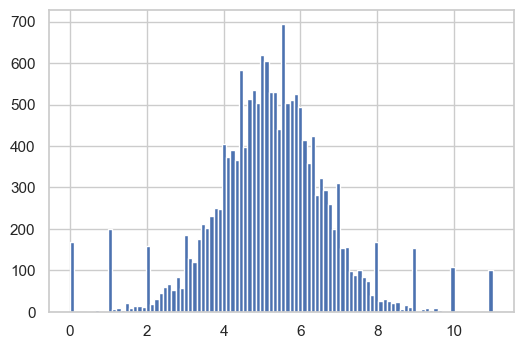

```python
# should we ask about pitch class ?

#I think we should ask about the keys. Because they should be intergers,
#but it's the case only for 17% of the data
#df.key[df.key.isin([k for k in range(-1,12)])].shape[0]/df.shape[0]
df.key.hist(bins = 100)
```

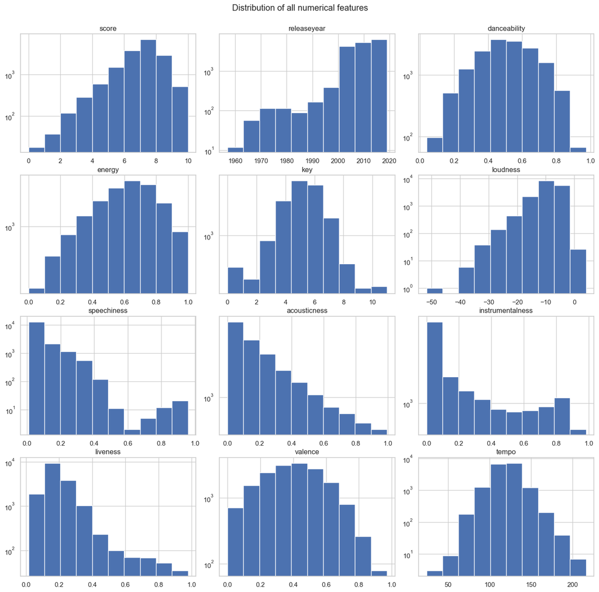

```python
fig, ax = plt.subplots(4,3,figsize= (14,14))#, sharex = 'row', sharey = 'row')

# list of names of numerical columns
num_cols = df.describe().loc[['mean', '50%', 'min', 'max']].columns.values
for i, elt in enumerate(num_cols):
    sbplt = ax[i//3, i%3]
    sbplt.hist(df[elt])#, bins = 100)
    sbplt.set_title(elt)
    sbplt.set_yscale('log')

fig.tight_layout(pad=0.5)
fig.subplots_adjust(top=0.93)

plt.suptitle('Distribution of all numerical features');
```

1. For categorical columns, list how many different values there are in each column. If there are less than 10 distinct values for a category, print them all. For the `genre` column, assign the value `'Other'` for albums where the value is either `'none'` or `NaN`.

```python
to_modif = (df.genre == 'none') | (df.genre.isna())
df.loc[to_modif, 'genre'] = 'Other'

print(f"There were {to_modif.sum()} genre values replaces by 'Other'.")
```

```
There were 11 genre values replaces by 'Other'.
```

```python
# list of categorical columns
cat_cols = df.columns.difference(num_cols)

for cat in cat_cols:
    n = df[cat].unique().size
    if n <= 10:
        print(f'"{cat}" column has {n} distinct values : \n{", ".join(df[cat].unique())}.')
    else :
        print(f'"{cat}" column has {n} distinct values.')
    print()
```

```
"album" column has 16176 distinct values.

"artist" column has 7890 distinct values.

"genre" column has 10 distinct values :
Electronic, Folk/Country, Rock, Rap, Global, Experimental, Metal, Pop/R&B, Jazz, Other.

"recordlabel" column has 3030 distinct values.

"reviewauthor" column has 554 distinct values.

"reviewdate" column has 4876 distinct values.
```

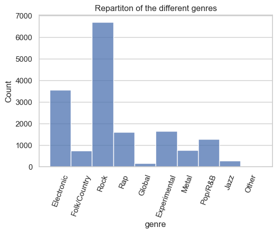

```python
sns.histplot(x = 'genre', stat = 'count', data = df[cat_cols])
plt.xticks(rotation=70);
plt.grid(axis = 'x', b = None)

#Y/N ?
#plt.yscale('log')
plt.title('Repartiton of the different genres');
```

1. **Discuss:** This dataset was built with *found data*—i.e., the Pitchfork reviews were not made with the goal of training a machine learning model. Grounded on the previous analyses and in Pitchfork's Wikipedia page), point **three** (exactly!) ways in which this data may not be representative of music albums in general due to the way the data was collected.

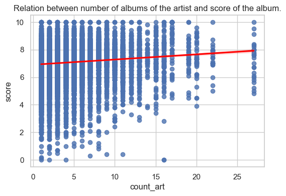

```python
df_test = df.copy()
count_art = df.artist.value_counts()
count_art.name = 'count_art'
df_test = df_test.merge(count_art,right_index=True, left_on='artist', how='inner')
sns.regplot(data=df_test, y = 'score', x='count_art', line_kws={'color': 'red'} )
plt.title('Relation between number of albums of the artist and score of the album.');
```

#### **Task 2 (Pre-processing and pipeline code — 12 pts)**

Next, you decide to prepare the code that will help you in training your machine learning models. Also, you implement a simple baseline. For this task, **unless otherwise stated** you must implement functions yourself, instead of relying on `scikit-learn` (you can use `numpy` or `pandas`, though!).

1. For each possible value in the `genre` column, create a new column called `{genre}_onehot` (e.g., for `genre=jazz`, create `jazz_onehot`). Collectively, these new columns should "one hot-encode" the genre column—for instance, if for a given album the `genre` is filled with the value `jazz`, the `jazz_onehot` column should equal 1 and all other `{genre}_onehot` columns should equal 0.

```python
onehot = pd.get_dummies(df.genre)
onehot.columns = [c+'_onehot' for c in onehot.columns]
onehot.head()
```

|  | Electronic_onehot | Experimental_onehot | Folk/Country_onehot | Global_onehot | Jazz_onehot | Metal_onehot | Other_onehot | Pop/R&B_onehot | Rap_onehot | Rock_onehot |
| --- | --- | --- | --- | --- | --- | --- | --- | --- | --- | --- |
| 0 | 1 | 0 | 0 | 0 | 0 | 0 | 0 | 0 | 0 | 0 |
| 1 | 0 | 0 | 1 | 0 | 0 | 0 | 0 | 0 | 0 | 0 |
| 2 | 1 | 0 | 0 | 0 | 0 | 0 | 0 | 0 | 0 | 0 |
| 3 | 0 | 0 | 0 | 0 | 0 | 0 | 0 | 0 | 0 | 1 |
| 4 | 0 | 0 | 0 | 0 | 0 | 0 | 0 | 0 | 1 | 0 |

1. Create a function `numpy_helper(df, cols)` to obtain a `numpy.array` out of your `dataframe`. The function should receive a dataframe `df` with N rows and a list of M columns `cols`, and should return a `np.array` of dimension (NxM).

```python
def numpy_helper(df, cols):
    '''Return the numpy array of selected cols in df.'''
    return df[cols].values
```

1. For each album, build an array of features `X` containing all genre-related one-hot features, and an array of outcomes `y` containing scores. Using the function [`sklearn.model_selection.train_test_split`](https://scikit-learn.org/stable/modules/generated/sklearn.model_selection.train_test_split.html) with `random_state=123`, split the data into a train set containing 70% of all data, and a test set containing the remaining 30%.

```python
X = numpy_helper(onehot, onehot.columns)
y = numpy_helper(df, 'score')
X_train, X_test, y_train, y_test = train_test_split(X, y, test_size = 0.3, random_state=123)
```

1. Create your own baseline regressor. Using the training data (in the training stage), your regressor should estimate the average score for all albums. Then, for the test data (in the prediction stage), your classifier should always output the average score (computed on the training data).

```python
class Baseline():
    def __init__(self):
        self.avg = None

    def fit(self, X, y):
        self.avg = np.mean(y)

    def predict(self, X):
        return self.avg * np.ones((X.shape[0],))
```

```python
baseline = Baseline()
baseline.fit(X_train, y_train)
```

1. Calculate the [coefficient of determination ($R^2$)](https://scikit-learn.org/stable/modules/generated/sklearn.metrics.r2_score.html) of your baseline on the test data. **You are allowed to use the `sklearn` implementation here.**

```python
r2_score(y_test, baseline.predict(y_test))
```

```
-1.0839329994682956e-05
```

As expected, the $R^2$ of the baseline is very close to 0.

1. **Discuss:** Your train-test split randomly selected 70% of all data for the training set. Why is this a problem for the broader task of predicting whether a future album will be successful or not?

A random split doesn't necessarily take into account the underlying distribution of data. We might want to ensure that the model is evaluated on every example, for example by using $k$-fold instead of only one train-test split.

**Task 3 (Regression — 14 pts)**

Finally, you get down to business and train your regression models.

1. Build a Linear Regression model (use `sklearn`) that predicts the outcome `score` using the features "releaseyear", "key", "acousticness", "danceability", "energy", "instrumentalness", "liveness", "loudness", "speechiness", "valence", "tempo" and the one-hot encoded genre-related columns. Using a 70/30 train-test split similar to what you did in task two (hereinafter referred to as "the random split", use the same random seed, `random_state=123`), report the $R^2$ for the testing set.a

```python
model = LinearRegression()

# data conversion to numpy array and random splitting
df_onehot = pd.merge(df, onehot, left_index=True, right_index=True)
cols = [ "releaseyear", "key", "acousticness", "danceability",
        "energy", "instrumentalness", "liveness", "loudness",
        "speechiness", "valence", "tempo"] + list(onehot.columns)
X,y = numpy_helper(df_onehot, cols), numpy_helper(df_onehot, 'score')
X_train, X_test, y_train, y_test = train_test_split(X, y, test_size = 0.3, random_state=123)

#model training
model.fit(X_train, y_train)

print(f"The R^2 of the linear regression on the random split is {r2_score(y_test, model.predict(X_test)):.4f}.")
```

```
The R^2 of the linear regression on the random split is 0.0387.
```

1. Create an alternate train-test split (hereinafter referred to as "the longitudinal split") where you train with data from albums released before 2000 and test with data from 2003 and after. Report the $R^2$ for the testing set using the same model you developed for the previous question. **Discuss:** give the correct interpretation of $R^2$ value for the longitudinal split.

```python
model = LinearRegression()

#copy to silence setting on copy warnings arising later
df_train = df_onehot[df_onehot.releaseyear < 2000].copy()
df_test = df_onehot[df_onehot.releaseyear >= 2003].copy()

X_train,y_train = numpy_helper(df_train, cols), numpy_helper(df_train, 'score')
X_test ,y_test  = numpy_helper(df_test, cols) , numpy_helper(df_test, 'score')

#model training
model.fit(X_train, y_train)

print(f"The R^2 of the linear regression on the longitudinal split is {r2_score(y_test, model.predict(X_test)):.4f}.")
```

```
The R^2 of the linear regression on the longitudinal split is -0.2823.
```

The $R^2$ is actually negative for a linear regression using the longitudinal split. This means that the prediction is worth than the average of over the test set. This is not surprising, as the distribution of scores changes drastically after 1999 (cf Task 1). Because of this, the distribution of scores is very different between train et test set with the longitudinal split.

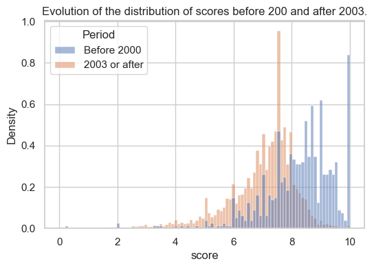

```python
df_train.loc[:,'Period'] = 'Before 2000'
df_test.loc[:,'Period'] = '2003 or after'
df_plot = pd.concat((df_train, df_test), axis=0)
sns.histplot(df_plot, x='score', hue='Period', common_norm=False, stat='density')
plt.title('Evolution of the distribution of scores before 200 and after 2003.');
```

1. For a given entry $X$ your model outputs a predicted score $Y'$. The difference between the real score $Y$ and the predicted score $Y'$ is called the "residual". Considering the model trained in 3.2, plot the distribution of your residuals for the test set. Additionally, estimate what is the probability that your score prediction (from 3.2) is off by more than 2-points? Provide bootstrapped confidence intervals for your answer.

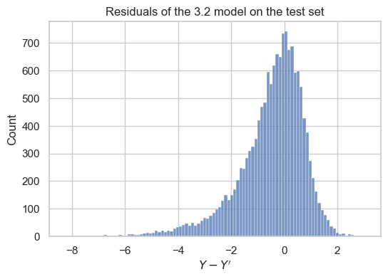

```python
y_pred = model.predict(X_test)
sns.histplot(x=y_test - y_pred)
plt.title('Residuals of the 3.2 model on the test set')
plt.xlabel("$Y- Y'$");
```

This distribution is not Gaussian, as the linear model expects. Indeed, it is left-skewed, which is expected since the test set is shifted left compared to the train set.

```python
#bootstrap CI
N = 10_000
proba = np.zeros(N)
n = y_test.size

for i in range(N):
    idx = rng.integers(0,n,n) # n integers between 0 and n : indices of the samples
    y_sample = y_test[idx]
    X_sample = X_test[idx]
    y_pred = model.predict(X_sample)
    err = np.where(np.abs(y_pred - y_sample) > 2, 1, 0) #1 if |res| > 2, else 0
    proba[i] = err.mean()
```

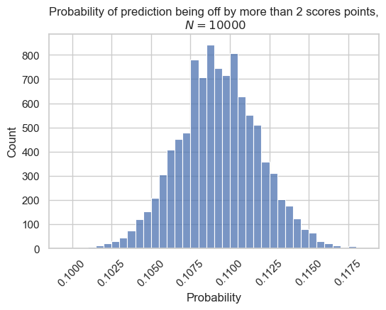

```python
sns.histplot(x=proba, binwidth=5e-4)
plt.xlabel('Probability')
plt.title(f'Probability of prediction being off by more than 2 scores points,\n $N = {N}$')
plt.xticks(rotation = 45);
```

```python
pmin, pmax = np.quantile(proba, [0.025, 0.975])
print(f"With the model trained in 3.2, the error is more than 2 points of score with a probability "+
     f"between {pmin:.4f} and \n{pmax:.4f} (95% C.I., {N} bootstrap samples).")
```

```
With the model trained in 3.2, the error is more than 2 points of score with a probability between 0.1042 and
0.1144 (95% C.I., 10000 bootstrap samples).
```

1. Experiment with training a different regressor, a Gradient Boosting Regressor. This regressor is related to the Boosted decision trees that you have seen in class. This model performs extremely well for a variety of tasks and is often used in machine learning competitions for tabular data (e.g., on Kaggle). Train the regressor using the longitudinal split and the same features as in 3.2, use the default hyperparameters. Report the $R^2$ for the testing set.

```python
model = GradientBoostingRegressor()
model.fit(X_train, y_train)
print(f"The R^2 of the Gradient Boosting Regressor on the longitudinal split"+\
      f"is {r2_score(y_test, model.predict(X_test)):.4f}.")
```

```
The R^2 of the Gradient Boosting Regressor on the longitudinal splitis -0.4104.
```

1. **Discuss:** Hypothesize a reason for the difference in performance between the Linear regression and the Gradient Boosting Regressor.

The train/test split is not adapted at all to score a model for this task, given the difference in distribution between the two. It's likely that the Gradient Booster regressor performs better than the Linear Regression, but that this better performance translates into a worse score on the test set. One could call that "overfitting", but really the problem lies *a priori* with the data split and not the model.

**Task 4 (Are we solving the correct problem? — 16 pts)**

All your efforts so far have assumed that decisions are taken at the "album" level, which is often not the case for bands with multiple albums. In those cases, it could be interesting to predict what is the success of a given band album given the features of the album **and of previous albums**.

1. Create a new dataframe that contains one row per band with more than 1 album. This dataframe should have the same columns as the data provided to you, considering the latest album of the respective band (note that this is determined by the release year of the album, not the date when it was reviewed). Additionally, for each feature considered in Task 3.1 (including the one-hot encoded features), create an additional column post-fixed with `_previous` (e.g., `danceability_previous`). These columns should contain the average values for all of the band's previous albums. Also, create a column `score_previous` with the average score of previous albums. Print the number of rows in the dataframe as well as the name of the columns.

```python
# find artists with several albums
counts = df.groupby('artist').releaseyear.count()
artists = counts[counts>1].index

# find latest albums.
latest = df[df.artist.isin(artists)].sort_values('reviewdate', ascending=False).groupby('artist').releaseyear.idxmax()
df_latest = df_onehot.loc[latest]

# find rows about previous albums.
previous = df[df.artist.isin(artists)].index.difference(latest)
df_previous = df_onehot[cols+['score', 'artist']].loc[previous]
avg_previous = df_previous.groupby('artist').mean()

# merge both dataframes
df_latest = df_latest.merge(df_previous, right_on='artist', left_on='artist', suffixes=('','_previous'))
```

```python
print(f"The resulting dataframe has {df_latest.shape[0]} rows and the following columns :")
print(', '.join(df_latest.columns))
```

[output not shown]

1. Train a Gradient Boosting Regressor considering all features created in Task 4.1 (note that `score` is the outcome and everything else is a feature, including `score_previous`). Use the 70/30 random train-test split, the default hyperparameters, and report the $R^2$ for the testing set.

```python
model = GradientBoostingRegressor()

# data conversion to numpy array and random splitting
cols_latest = cols + [s+"_previous" for s in cols] + ["score_previous"]
X,y = numpy_helper(df_latest, cols), numpy_helper(df_latest, 'score')
X_train, X_test, y_train, y_test = train_test_split(X, y, test_size = 0.3, random_state=123)

#model training
model.fit(X_train, y_train)

print(f"The R^2 of the Gradient Boosting regression on the random split with the new features is "+\
      f"{r2_score(y_test, model.predict(X_test)):.4f}.")
```

```
The R^2 of the Gradient Boosting regression on the random split with the new features is 0.2272.
```

1. Can hyperparameter tuning improve your model? Write modular code (i.e., a function) to divide your training data into $N$ folds and perform cross-validation. Experiment tuning two hyperparameters of the Gradient Boosting Regressor: `n_estimators` and `learning_rate`. For each possible combination of the two hyperparameters (see below for the range of values that you should try for each hyperparameter), train your model in a cross-validation setup with $N=20$ folds. Report the mean $R^2$ along with the 90% CI for each scenario.
   - n_estimators $ \in \{ 100, 200, 300, 400\}$
   - learning_rate $ \in \{ 0.1, 0.05, 0.01\}$.

   With the best hyperparameters obtained, train your model with the entire training set and report the $R^2$ on the testing set.

```python
def cross_valid(X,y,model, k=5):
    """Perform k_fold cross validation on model.
    Returns an array containing the R^2 obtained on each split"""
    N = y.size
    ids = rng.permutation(N)
    # split the indices in k parts. If N%k != 0, we leave the N%k remaining data points out of the split.
    split = [ids[i * N//k : (i+1) * N//k ] for i in range(k)]
    acc=np.zeros(k)
    for i in range(k):
        id_test = split[i]
        id_train = np.concatenate([split[j] for j in range(k) if j!= i])
        model.fit(X[id_train], y[id_train])
        ypred = model.predict(X[id_test])
        acc[i] = r2_score(y[id_test], ypred)
    return acc
```

```python
n_est_vals = [100, 200, 300, 400]
lr_vals = [0.1, 0.05, 0.01]
k = 20
CI_cst = 1.96 /np.sqrt(k)

results = []
for n_est in n_est_vals:
    for lr in lr_vals:
        print(n_est, lr)
        model = GradientBoostingRegressor(learning_rate=lr, n_estimators=n_est)
        r2 = cross_valid(X_train, y_train, model, k=k)
        for s in r2 :
            results.append((n_est, lr, s))

cv_results = pd.DataFrame(results, columns = ['n_estimators', 'learning_rate', 'R2'])
```

```
100 0.1
100 0.05
100 0.01
200 0.1
200 0.05
200 0.01
300 0.1
300 0.05
300 0.01
400 0.1
400 0.05
400 0.01
```

```python
r2_stats = cv_results.groupby(['n_estimators','learning_rate']).agg([np.mean, np.std])
idmax, meanmax = r2_stats[('R2','mean')].idxmax(), r2_stats[('R2','mean')].max()
r2_ci = r2_stats[('R2','std')][idmax]*CI_cst
print(f"The best R^2 score is {meanmax:.3f} +/- {r2_ci:.3f} (95% C.I.),\n"+\
      f"reached for (n_estimators, learnin_rate) = {idmax}.")
```

```
The best R^2 score is 0.391 +/- 0.025 (95% C.I.),
reached for (n_estimators, learnin_rate) = (400, 0.1).
```

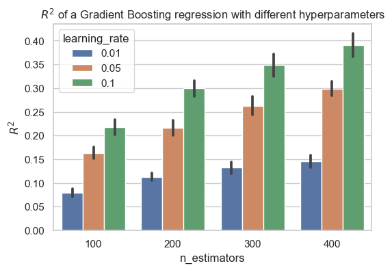

```python
sns.barplot(data=cv_results, x='n_estimators',hue='learning_rate',y='R2',ci=95)
plt.title('$R^2$ of a Gradient Boosting regression with different hyperparameters');
plt.ylabel('$R^2$');
```

```python
n_est, lr = idmax
model = GradientBoostingRegressor(learning_rate=lr, n_estimators=n_est)
model.fit(X_train, y_train)
r2_best = r2_score(y_test,model.predict(X_test))
print(f'The R^2 score of the model with the best hyperparameters (lr = {lr}, n_estimators = {n_est})'+\
      f'\non the test set is {r2_best:.4f}.')
```

```
The R^2 score of the model with the best hyperparameters (lr = 0.1, n_estimators = 400)
on the test set is 0.4081.
```

1. **Discuss:** How do these results compare with the previous setup (the scenario considered in **Task 3.4**)? Point out two reasons why it is hard to compare the results obtained in 4.3 and 3.4 at face value? How would you fairly compare the two different setups?

This results are obviously far better than those in task 3.4, given that we now have a positive $R^2$. However, this setups are really not easy to compare, for several reasons : - We don't use the same train/test split in the two setups, and the longitudinal split used in task 3.4 probably makes it more difficult to have a good accuracy, since the distribution of $y$ is different on the train and test set. - We use neither the same features nor the same model in the two settings. For that reason, we can't easily attribute any improvement to the change in model or in features. To fairly compare this two setups, we would use the same train/test split, the random 70/30 split. Then, we would observe the scores of the linear and Gradient Boosting regressions once on each set of features. This way, we can compare different models using the same features, and different features with the same models.

## Part 2: Second Album Syndrome

Your second project at *Piccardi Music* is to shed light on one of the business's oldest enigmas: the "second album syndrome." In a nutshell, the "second album syndrome" is a theory that states that the second album of a band always sucks. ([Related read](https://tvtropes.org/pmwiki/pmwiki.php/Main/SophomoreSlump))

Assume—for the purpose of this task—that the Pitchfork data contains all albums for all artists it covers (even though this might not be true in reality).

**Task 5 (Preliminary analyses — 8 pts)**

You begin by carrying out some preliminary data processing and analyses.

1. Create a new dataframe (from the original data with duplicates dropped, the same as you obtained after finishing Task 1.1) containing only albums from artists with two or more albums and where the release year is not empty.

```python
# We merged the cells of the Task1 in this one
# Import the Database
df = pd.read_csv(DATA_FOLDER + 'pitchfork.csv.gz', compression='gzip', dtype={'releaseyear': int},
                 usecols = ['artist', 'album', 'score', 'releaseyear', 'reviewdate', 'danceability',
                            'energy', 'key', 'loudness','speechiness', 'acousticness', 'instrumentalness',
                            'liveness', 'valence', 'tempo'], parse_dates=['reviewdate'])

# Drop the duplicates
shape_before = df.shape[0]
df.drop_duplicates(subset = ['artist','album'], keep = 'first', inplace = True)
print('After removing the duplicate reviews, the dataframe size decreased from {} to {} rows.'\
      .format(shape_before, df.shape[0]))

# Remove the irregular rows
aberrant_num_columns = ['danceability', 'energy', 'speechiness', 'acousticness', 'instrumentalness',
                        'liveness', 'valence', 'tempo']
to_drop = df[df[aberrant_num_columns].lt(0.0).any(axis = 1)].shape[0]
df = df[~df[aberrant_num_columns].lt(0.0).any(axis = 1)]
print('We removed {} rows with irregular values.'.format(to_drop))

# Keep artists that produced more than 1 album
artists_count_album = df.groupby('artist').agg('count').album
artists_more_1_album = artists_count_album[artists_count_album >1]
df = df[df.artist.isin(artists_more_1_album.index.values)]
print('We removed {} artists that produced only one album.'.format(artists_count_album[artists_count_album<2].shape[0]))

# Checking that the release years are well-known
df_releaseyear_isnull = df[df.releaseyear.isnull()]
print('There are {} album which releaseyear is empty.\n'.format(df_releaseyear_isnull.shape[0]))

print('To conclude, we have a database of {} albums, composed by {} different artists.'.format(df.shape[0],df.artist.unique().shape[0]))
```

```
After removing the duplicate reviews, the dataframe size decreased from 16785 to 16738 rows.
We removed 8 rows with irregular values.
We removed 4329 artists that produced only one album.
There are 0 album which releaseyear is empty.

To conclude, we have a database of 12401 albums, composed by 3561 different artists.
```

1. Create a new column `album_number` which indicates how many albums the artist has produced before this one (before the second album, the artist has already produced one album).

As the temporality is very important, and that the `releaseyear` feature gives only the year, what should we do about the artists that released their 2 first albums during the same year? After having read the posts on Zulip, and discussed with Manoel during the Lab session, we *admit* that if 2 albums were released the same year, we can sort them according the `reviewdate`. --- But at the end, we dropped this albums and redid the calculus. Spoiler: The results were comparable.

```python
#The df is timely sorted and grouped by artists and we use the function `cumcount`
df['album_number'] = df.sort_values(['releaseyear', 'reviewdate']).groupby('artist').cumcount()

#One exemple
df[df.artist == 'Muse'].sort_values(['releaseyear', 'reviewdate'])[['artist','album', 'releaseyear',
                                                                    'reviewdate', 'album_number']]
```

|  | artist | album | releaseyear | reviewdate | album_number |
| --- | --- | --- | --- | --- | --- |
| 11361 | Muse | Black Holes and Revelations | 2006 | 2006-07-05 | 0 |
| 8963 | Muse | H.A.A.R.P. | 2008 | 2008-04-16 | 1 |
| 96 | Muse | The Resistance | 2009 | 2009-09-15 | 2 |
| 15897 | Muse | The 2nd Law | 2012 | 2012-10-02 | 3 |
| 4014 | Muse | Drones | 2015 | 2015-06-09 | 4 |
| 1866 | Muse | Simulation Theory | 2018 | 2018-11-15 | 5 |

```python
#The first part counts the number of different `releaseyear` per group
#The secound one counts the number of `releaseyear` per group
#grp is a boolean Series that indicates for each group if it produced more than 1 album in 1 year

grp = df[df.album_number.isin([0,1])].groupby('artist')['releaseyear'].nunique() != \
df[df.album_number.isin([0,1])].groupby('artist')['releaseyear'].count()

print('There are {} groupes whose 2 first albums were realeased the same year.'\
      .format(grp[grp == True].shape[0]))

#One exemple
df[df.artist == '03 Greedo'].sort_values(['releaseyear', 'reviewdate'])[['artist','album', 'releaseyear',
                                                                    'reviewdate', 'album_number']]
```

```
There are 175 groupes whose 2 first albums were realeased the same year.
```

|  | artist | album | releaseyear | reviewdate | album_number |
| --- | --- | --- | --- | --- | --- |
| 11582 | 03 Greedo | The Wolf of Grape Street | 2018 | 2018-03-15 | 0 |
| 15027 | 03 Greedo | God Level | 2018 | 2018-07-05 | 1 |
| 15531 | 03 Greedo | Still Summer in the Projects | 2019 | 2019-04-24 | 2 |
| 16226 | 03 Greedo | Netflix & Deal | 2019 | 2019-12-05 | 3 |

1. Calculate the mean and the standard error fo the mean of the scores of the first and second albums in the dataset. Additionally, plot the two distributions.

```python
df[['score','album_number']].groupby('album_number').agg(['mean', 'std']).iloc[[0,1]]
```

| album_number | score mean | score std |
| --- | --- | --- |
| 0 | 7.303229 | 1.235374 |
| 1 | 7.038978 | 1.273217 |

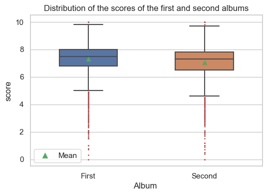

```python
flierprops = dict(marker='.', markerfacecolor='g', markersize=2, linestyle='none', markeredgecolor='r')
sns.boxplot(x = 'album_number', y = 'score', data = df[df.album_number.isin([0,1])],
            flierprops = flierprops, width = 0.5, showmeans=True);

legend_elements = [Line2D([0], [0], marker='^', color='w', label='Mean', markerfacecolor='g', markersize=10)]
plt.legend(handles=legend_elements)

plt.xticks([0,1], ['First', 'Second']);
plt.xlabel('Album ');
plt.title('Distribution of the scores of the first and second albums');
```

1. Use an appropriate method to determine if the difference in means of 1st and 2nd albums is statistically significant?

```python
ttest, pvalue, degf = sm.stats.ttest_ind(df[df.album_number == 0].score, df[df.album_number == 1].score)


print('We decided to apply a t-test, the p-value is about {:.3E},ie we can reject the'.format(pvalue) +\
' null hypothesis \n(the 2 tested populations have the same score mean) with an risk error smaller than 99%.')
```

```
We decided to apply a t-test, the p-value is about 7.726E-19,ie we can reject the null hypothesis
(the 2 tested populations have the same score mean) with an risk error smaller than 99%.
```

1. **Discuss:** Do these analyses suggest that the "second album syndrome" exists?

According to the t-test on the score observed for the first and the second album on the cleaned data, it seems that the difference of score is significative ($p < 0.01$). That would suggest that the "second album syndrome" theory is **true**. This theory claims that the quality of a second album is often worst than the first one, ie is less appreciated.

**Task 6 (Regression analysis — 20 pts)**

Next, you proceed to examine some hypotheses about the "second album syndrome" using a regression framework. Namely:

- The **time spent hypothesis:** the first album usually has a couple of years of development under its belt and plenty of trial and error from live concerts to help the band determine what does or doesn't work. The second album, on the other hand, is often made in a rush.
- The **style change hypothesis:** bands often try to change their style after their first album. This change is not always welcomed by the listeners.
1. Create a new dataframe containing one row per 1st-2nd album pair. The dataframe should contain rows:
   - `score_diff`: the difference in scores between the second and the first album (second - first).
   - `time_diff`: the number of days elapsed between the first and the second album.
   - `did_style_change`: a dummy variable that indicates whether the style of the music has changed. To obtain it, first, calculate the [standardized euclidean distance](https://docs.scipy.org/doc/scipy/reference/generated/scipy.spatial.distance.seuclidean.html) of music-related numerical features¹ between the second and the first album. Second, assign 1 to the 20% most distant 1st-2nd album pairs and 0 to all others.

¹ Music related numerical features are: "key", "acousticness", "danceability", "energy", "instrumentalness", "liveness", "loudness", "speechiness", "valence", and "tempo".

In order to create the new dataframe, we: 1. Create a new dataframe `df`, by merging the sub dataframes (`album_number` == 0 or 1) according to the `artist`. (The parameter `validate = "1:1"` checks if merge keys are unique in both left and right datasets). To differentiate the features of the second album (ie `album_number` == 1), we added the suffix `_1` to the corresponding name of the column. To make the df lighter we dropped the columns that are no longer useful. In `df2`, one row corresponds to the data of the 2 first albums of one artist. 2. Compute and add the `score_diff` column. 3. Compute and add the `time_diff` column (assuming that one year = 365 days). 4. Define a function that returns the standardized euclidean distance of music-related numerical features for the 2 first albums. 5. Apply it. 6. Finally create the `did_it_change` columns that is worth 1 for the 20% highest scores.

```python
# 1. Merging
df2 = df[df.album_number ==0].merge(df[df.album_number ==1], how='inner', on='artist',
                                    suffixes=('', '_1'), validate = "1:1")

df2.drop(columns=['album_number', 'album_number_1'], inplace=True)

# 2. Score_diff
df2['score_diff'] = df2.score_1 - df2.score
df2.drop(columns=['score_1', 'score'], inplace=True)

# 3. Time-diff
df2['time_diff'] = (df2.releaseyear_1 - df2.releaseyear)*365
df2.drop(columns=['releaseyear_1', 'releaseyear'], inplace=True)
```

```python
# 4. Function computing the distance of 2 albums

#The numerical features
num_feat = ["key", "acousticness", "danceability", "energy", "instrumentalness",
                "liveness", "loudness", "speechiness", "valence", "tempo"]
num_feat_1 = [k + '_1' for k in num_feat]

#variances for the standardized euclidean distance
var = df[df.album_number.isin([0,1])][num_feat].var()

def euclidean_dist(albums):
    u, v = albums[num_feat], albums[num_feat_1]

    return seuclidean(u,v, var)
```

```python
# 5. Application
df2['euclidean_dist'] = df2.apply(euclidean_dist, axis = 1)

# 6. Creation of the column
df2['did_style_change'] = 0
lim = round(df2.shape[0]*0.2)

index_1 = df2.sort_values('euclidean_dist', ascending = False).iloc[0:lim].index
df2.loc[index_1, 'did_style_change'] = 1

df2.drop(columns = num_feat + num_feat_1 + ['euclidean_dist'], inplace = True)
```

1. Fit a linear regression using `statsmodels` with this dataframe. Your regression should consider only an intercept, i.e., `"score_diff ~ 1"`.

```python
# Declare the model
mod = smf.ols(formula='score_diff ~ 1', data=df2)

# Fits the model (find the optimal coefficients, adding a random seed ensures consistency)
np.random.seed(2)
res = mod.fit()

# Print thes summary output provided by the library.
print(res.summary())
```

```
                            OLS Regression Results
==============================================================================
Dep. Variable:             score_diff   R-squared:                       0.000
Model:                            OLS   Adj. R-squared:                  0.000
Method:                 Least Squares   F-statistic:                       nan
Date:                Fri, 19 Nov 2021   Prob (F-statistic):                nan
Time:                        20:44:45   Log-Likelihood:                -6195.2
No. Observations:                3561   AIC:                         1.239e+04
Df Residuals:                    3560   BIC:                         1.240e+04
Df Model:                           0
Covariance Type:            nonrobust
==============================================================================
                 coef    std err          t      P>|t|      [0.025      0.975]
------------------------------------------------------------------------------
Intercept     -0.2643      0.023    -11.440      0.000      -0.310      -0.219
==============================================================================
Omnibus:                      400.832   Durbin-Watson:                   1.998
Prob(Omnibus):                  0.000   Jarque-Bera (JB):             2191.611
Skew:                          -0.394   Prob(JB):                         0.00
Kurtosis:                       6.762   Cond. No.                         1.00
==============================================================================

Notes:
[1] Standard Errors assume that the covariance matrix of the errors is correctly specified.
```

1. **Discuss:** Interpret the $R^2$ in your regression here. Does this analysis confirm what you observed in Task 5? Why?

The model `score_diff ~ 1` consideres that the difference of score is independent of the predictors. In other word, we are trying to see **if the evolution of the scores is aleatory or not**. $R^2$ corresponds to the fraction of explained variance, which indicates how well our model fits to the data. The more $R^2$ is close to one, the best the model is. In our case $R^2$ is null, so **the intercept model is terrible**! -- However, an intercept-only model has, by definition, no variance, so it explains none of the variance of the observed data. For that reason, we logically have $R^2=0$ for this model. In Task 5, with a t-test, we rejected the null-hypothesis (the mean-score of the first and the second album are the same), ie there is a significant difference of score. **This is confirmed here**, as the $p$-value of the intercept is lower than 0.001.

1. Include the `time_diff` and `did_style_change` as covariates in your model. Fit the regression again and report the summary of your model.

```python
# Declare the model
mod = smf.ols(formula='score_diff ~ time_diff + C(did_style_change)', data=df2)

# Fits the model (find the optimal coefficients, adding a random seed ensures consistency)
np.random.seed(2)
res = mod.fit()

# Print thes summary output provided by the library.
print(res.summary())
```

```
                            OLS Regression Results
==============================================================================
Dep. Variable:             score_diff   R-squared:                       0.018
Model:                            OLS   Adj. R-squared:                  0.017
Method:                 Least Squares   F-statistic:                     31.73
Date:                Fri, 19 Nov 2021   Prob (F-statistic):           2.19e-14
Time:                        20:44:49   Log-Likelihood:                -6163.7
No. Observations:                3561   AIC:                         1.233e+04
Df Residuals:                    3558   BIC:                         1.235e+04
Df Model:                           2
Covariance Type:            nonrobust
============================================================================================
                               coef    std err          t      P>|t|      [0.025      0.975]
--------------------------------------------------------------------------------------------
Intercept                   -0.1349      0.029     -4.586      0.000      -0.193      -0.077
C(did_style_change)[T.1]    -0.0673      0.057     -1.175      0.240      -0.180       0.045
time_diff                -8.824e-05   1.12e-05     -7.849      0.000      -0.000   -6.62e-05
==============================================================================
Omnibus:                      371.065   Durbin-Watson:                   2.002
Prob(Omnibus):                  0.000   Jarque-Bera (JB):             2056.531
Skew:                          -0.336   Prob(JB):                         0.00
Kurtosis:                       6.662   Cond. No.                     6.21e+03
==============================================================================

Notes:
[1] Standard Errors assume that the covariance matrix of the errors is correctly specified.
[2] The condition number is large, 6.21e+03. This might indicate that there are
strong multicollinearity or other numerical problems.
```

1. **Discuss:** Interpret the coefficients `time_diff` and `did_style_change`. Carefully explain whether they provide evidence towards each of the aforementioned hypotheses? Do they rule out other reasons that may cause the "second album syndrome effect"?

1. Create a new column called `time_diff_standardized`. It should be a standardized version of the `time_diff` column. Repeat the regression done in 6.4 using the `time_diff_standardized` column instead of the `time_diff` column.

```python
df2['time_diff_standardized'] = (df2.time_diff-df2.time_diff.mean())/df2.time_diff.std()

# Declare the model
mod = smf.ols(formula='score_diff ~ time_diff_standardized + C(did_style_change)', data=df2)

# Fits the model (find the optimal coefficients, adding a random seed ensures consistency)
np.random.seed(2)
res = mod.fit()

# Print thes summary output provided by the library.
print(res.summary())
```

```
                            OLS Regression Results
==============================================================================
Dep. Variable:             score_diff   R-squared:                       0.018
Model:                            OLS   Adj. R-squared:                  0.017
Method:                 Least Squares   F-statistic:                     31.73
Date:                Fri, 19 Nov 2021   Prob (F-statistic):           2.19e-14
Time:                        20:44:52   Log-Likelihood:                -6163.7
No. Observations:                3561   AIC:                         1.233e+04
Df Residuals:                    3558   BIC:                         1.235e+04
Df Model:                           2
Covariance Type:            nonrobust
============================================================================================
                               coef    std err          t      P>|t|      [0.025      0.975]
--------------------------------------------------------------------------------------------
Intercept                   -0.2508      0.026     -9.795      0.000      -0.301      -0.201
C(did_style_change)[T.1]    -0.0673      0.057     -1.175      0.240      -0.180       0.045
time_diff_standardized      -0.1798      0.023     -7.849      0.000      -0.225      -0.135
==============================================================================
Omnibus:                      371.065   Durbin-Watson:                   2.002
Prob(Omnibus):                  0.000   Jarque-Bera (JB):             2056.531
Skew:                          -0.336   Prob(JB):                         0.00
Kurtosis:                       6.662   Cond. No.                         2.62
==============================================================================

Notes:
[1] Standard Errors assume that the covariance matrix of the errors is correctly specified.
```

1. **Discuss:** Explain how the interpretation of the coefficients associated with this new column `time_diff_standardized` differ from its non-standardized version `time_diff`?

```python
df2.time_diff.std()
```

```
2038.0643772751785
```

We have now to take the standardization into account. As the values are of the magnitude of 1 (and not 300-1000), the coefficient corresponding to the predictors increased.

--- We create the dataframe `df_bis`by dropping the artists that produced they 2 first albums the same year and reapply all the opeartions of the task.

```python
diff = df[df.album_number.isin([0,1])].groupby('artist')['releaseyear'].nunique() != \
df[df.album_number.isin([0,1])].groupby('artist')['releaseyear'].count()
to_drop = diff[diff].index

print(f'There are {len(to_drop)} artists that produced more than 1 album in 1 year.\n')

df_bis = df[~df.artist.isin(to_drop)]
```

```
There are 175 artists that produced more than 1 album in 1 year.
```

```python
ttest_2, pvalue_2, degf_2 = sm.stats.ttest_ind(df_bis[df_bis.album_number == 0].score, df_bis[df_bis.album_number == 1].score)


print('We the new data, the p value passes from {:.3E} to {:.3E}.'.format(pvalue, pvalue_2))
```

```
We the new data, the p value passes from 7.726E-19 to 2.258E-19.
```

The p-value is similar witout the drop or not.

```python
# 1. Merging
df2 = df_bis[df_bis.album_number ==0].merge(df_bis[df_bis.album_number ==1], how='inner', on='artist',
                                    suffixes=('', '_1'), validate = "1:1")

df2.drop(columns=['album_number', 'album_number_1'], inplace=True)

# 2. Score_diff
df2['score_diff'] = df2.score_1 - df2.score
df2.drop(columns=['score_1', 'score'], inplace=True)

# 3. Time-diff
df2['time_diff'] = (df2.releaseyear_1 - df2.releaseyear)*365
df2.drop(columns=['releaseyear_1', 'releaseyear'], inplace=True)

# 4. Function computing the distance of 2 albums
#The numerical features
num_feat = ["key", "acousticness", "danceability", "energy", "instrumentalness",
                "liveness", "loudness", "speechiness", "valence", "tempo"]
num_feat_1 = [k + '_1' for k in num_feat]

#variances for the standardized euclidean distance
var = df[df.album_number.isin([0,1])][num_feat].var()

# 5. Application
df2['euclidean_dist'] = df2.apply(euclidean_dist, axis = 1)

# 6. Creation of the column
df2['did_style_change'] = 0
lim = round(df2.shape[0]*0.2)

index_1 = df2.sort_values('euclidean_dist', ascending = False).iloc[0:lim].index
df2.loc[index_1, 'did_style_change'] = 1

df2.drop(columns = num_feat + num_feat_1 + ['euclidean_dist'], inplace = True)

# 7. Normalization
df2['time_diff_standardized'] = (df2.time_diff-df2.time_diff.mean())/df2.time_diff.std()

###################

# Declare the model
mod = smf.ols(formula='score_diff ~ time_diff_standardized + C(did_style_change)', data=df2)

# Fits the model (find the optimal coefficients, adding a random seed ensures consistency)
np.random.seed(2)
res = mod.fit()

# Print thes summary output provided by the library.
print(res.summary())
```

```
                            OLS Regression Results
==============================================================================
Dep. Variable:             score_diff   R-squared:                       0.017
Model:                            OLS   Adj. R-squared:                  0.017
Method:                 Least Squares   F-statistic:                     29.74
Date:                Fri, 19 Nov 2021   Prob (F-statistic):           1.57e-13
Time:                        20:46:27   Log-Likelihood:                -5856.9
No. Observations:                3386   AIC:                         1.172e+04
Df Residuals:                    3383   BIC:                         1.174e+04
Df Model:                           2
Covariance Type:            nonrobust
============================================================================================
                               coef    std err          t      P>|t|      [0.025      0.975]
--------------------------------------------------------------------------------------------
Intercept                   -0.2668      0.026    -10.170      0.000      -0.318      -0.215
C(did_style_change)[T.1]    -0.0384      0.059     -0.654      0.513      -0.153       0.077
time_diff_standardized      -0.1799      0.023     -7.662      0.000      -0.226      -0.134
==============================================================================
Omnibus:                      325.655   Durbin-Watson:                   2.010
Prob(Omnibus):                  0.000   Jarque-Bera (JB):             1766.036
Skew:                          -0.288   Prob(JB):                         0.00
Kurtosis:                       6.491   Cond. No.                         2.62
==============================================================================

Notes:
[1] Standard Errors assume that the covariance matrix of the errors is correctly specified.
```

The results of the regression analysis are the same ; ther is no signifiant changes. Hence, we conclude that the dropping had no effect and we keep the data undropped for the next task.

**Task 7 (Sanity checks — 6 pts)**

You decide to perform a few last sanity checks for your analysis.

1. **Discuss:** If the Second Album Syndrome existed, i.e., something was special about the second album (as in if it was bad for a very particular reason that afflicted album number 2 more than all others), what would you expect to happen to the mean score of the third album?

Supposing the "Second Album Syndrome" exists, and that the second album what particullarly worster than the other, we would expect the third album **to have a better score**.

1. Using the dataset you created in Task 5, calculate the mean and the standard error of the mean for the 1st, 2nd, 3rd, and 4th albums. Test whether the difference between the average score of the second and the third album is statistically significant.

```python
df_1to4 = df[df.album_number >2][['score', 'album_number']]
mean = df_1to4.groupby('album_number').agg('mean').iloc[0:4]
mean['std'] = mean.score.std()
mean
```

| album_number | score | std |
| --- | --- | --- |
| 3 | 7.040662 | 0.060296 |
| 4 | 6.926147 | 0.060296 |
| 5 | 7.059685 | 0.060296 |
| 6 | 7.033887 | 0.060296 |

```python
count_album = df.groupby('artist').album.count()
artist_to_keep = count_album[count_album>3].index.values
df_1to4 = df[df.artist.isin(artist_to_keep)][['score', 'album_number']]
mean = df_1to4.groupby('album_number').agg('mean').iloc[0:4]
mean['std'] = mean.score.std()
mean
```

| album_number | score | std |
| --- | --- | --- |
| 0 | 7.541851 | 0.218472 |
| 1 | 7.343803 | 0.218472 |
| 2 | 7.163837 | 0.218472 |
| 3 | 7.040662 | 0.218472 |

1. **Discuss:** Does this suggest that the Second Album Syndrome exists?

As the evolution of the score mean between the second and the third album is lower than the standard deviation of the mean of the scores of the four first albums, **it doesn't suggest that the "Second Album Syndrome" exists**.

**Task 8 (Eureka — 14 pts)**

Your boss, *Signor Piccardi*, proposes that you carry out a simulation to make things clearer. Assuming that:

- Each band $i$ has a "talent" $\mu_i$ , which is uniformally distributed between 2 and 8, i.e., $\mu_i \sim U_{[2,8]}$.
- When a band $i$ produces an album $j$, it has quality $s_j$. This score is normally distributed with mean $\mu_i$ and standard deviation $1$, i.e., $s_j \sim N(\mu_i, 1)$
- Talents are independent and identically distributed random variables.

Carry out the following simulation:

- Create 1000 hypothetical bands with intrinsic talents $\mu_i \sim U_{[2,8]}$ for $i \in [1,1000]$.
- Have each hypothetical band create a hypothetical album.
- Discard all bands whose albums received a score smaller than 6.
- For each of the remaining bands, create two additional albums.

Analyzing the scores obtained in this simulation, provide a coherent explanation for the scores obtained in Task 7.2.

**Hint:** You can use numpy to sample random variables (e.g. [numpy.random.normal](https://numpy.org/doc/stable/reference/random/generated/numpy.random.normal.html))

```python
talent = np.random.uniform(low=2, high=8, size=1000)
for k in range(1,4):
    exec(f'album_{k} = np.random.normal(loc=talent, scale=1.0, size=None)')
```

```python
df_test = pd.DataFrame(data = np.array([talent, album_1, album_2, album_3]).T,
                       columns = ['talent', 'album_1', 'album_2', 'album_3'])
df_test = df_test[df_test.album_1 >= 6]
```

```python
mean_test =  df_test.iloc[:,1:].agg('mean')
mean_test['std'] = mean_test.std()
pd.DataFrame(mean_test).T
```

|  | album_1 | album_2 | album_3 | std |
| --- | --- | --- | --- | --- |
| 0 | 7.258434 | 6.846698 | 6.850084 | 0.236745 |

```python
talent = np.random.uniform(low=2, high=8, size=1000)
for k in range(1,4):
    exec(f'album_{k} = np.random.normal(loc=talent, scale=1.0, size=None)')
df_test = pd.DataFrame(data = np.array([talent, album_1, album_2, album_3]).T,
                       columns = ['talent', 'album_1', 'album_2', 'album_3'])
df_test = df_test[df_test.album_1 >= 6]
mean_test =  df_test.iloc[:,1:].agg('mean')
mean_test['std'] = mean_test.std()
mean_test = pd.DataFrame(mean_test).T


for loop in range(1000):
    talent = np.random.uniform(low=2, high=8, size=1000)
    for k in range(1,4):
        exec(f'album_{k} = np.random.normal(loc=talent, scale=1.0, size=None)')
    df_test = pd.DataFrame(data = np.array([talent, album_1, album_2, album_3]).T,
                           columns = ['talent', 'album_1', 'album_2', 'album_3'])
    df_test = df_test[df_test.album_1 >= 6]
    mean_test_to_add =  df_test.iloc[:,1:].agg('mean')
    mean_test_to_add['std'] = mean_test_to_add.std()
    mean_test = mean_test.append(mean_test_to_add, ignore_index=True)
```

```python
mean_test.iloc[:,]
```

[output not shown]

```python
mean_test.columns.values
```

```
array(['album_1', 'album_2', 'album_3', 'std'], dtype=object)
```